# Reproducible Research Assignment 1

## Loading and preprocessing the data

Below, I first require the data.table package.

```r
require(data.table)
```

I then download the file into the working folder of my RStudio.

```r
x <- "http://d396qusza40orc.cloudfront.net/repdata%2Fdata%2Factivity.zip"
y <- "./downloaded.zip"
download.file(x, destfile=y, mode="wb")
```

The downloaded file is then unzipped. The “for” function checks how many files there are in the zipped folder, and selects the “.csv” file for loading. The resulting “.csv” file" is loaded under “mydata”

```r
unzip(y)
    listoffiles <<- unzip(y, list=T)
    for (i in 1:length(listoffiles$Name))
    {
      if (grepl ("csv", listoffiles[i]$Name) == TRUE) {
        mydata <<- fread(paste("./", listoffiles[i]$Name, sep=""))
      }
  else {
    mydata <<- fread(y)
  }
}
```

## What is the mean total number of steps taken per day?

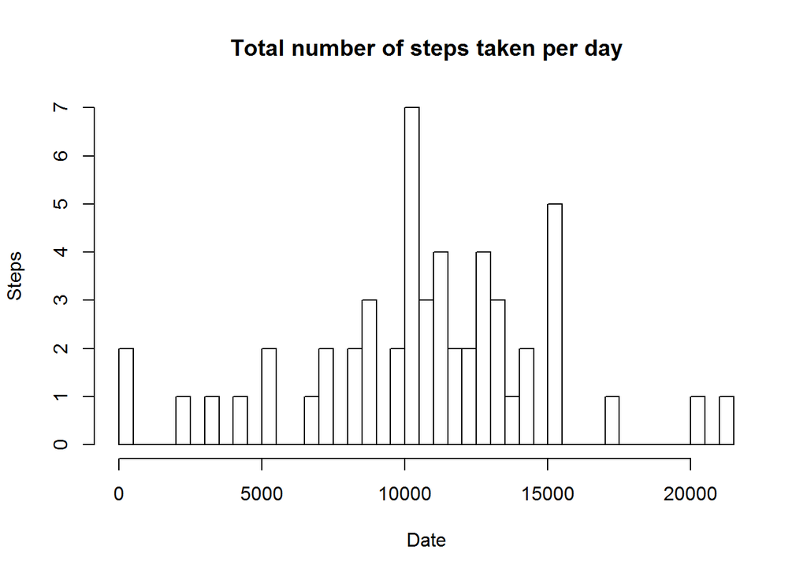

```r
AggregatedDates<- tapply(mydata$steps, mydata$date, FUN=sum)

#Breaks are set at 61, as there are 61 days from October to November.
hist(AggregatedDates, breaks = 61, xlab = "Date", ylab = "Steps", main = "Total number of steps taken per day")
```

```r
mean(AggregatedDates, na.rm = T)
```

```
## [1] 10766.19
```

```r
median(AggregatedDates, na.rm = T)
```

```
## [1] 10765
```

## What is the average daily activity pattern?

Next, I found out the average number of steps taken for each interval before plotting a line graph.

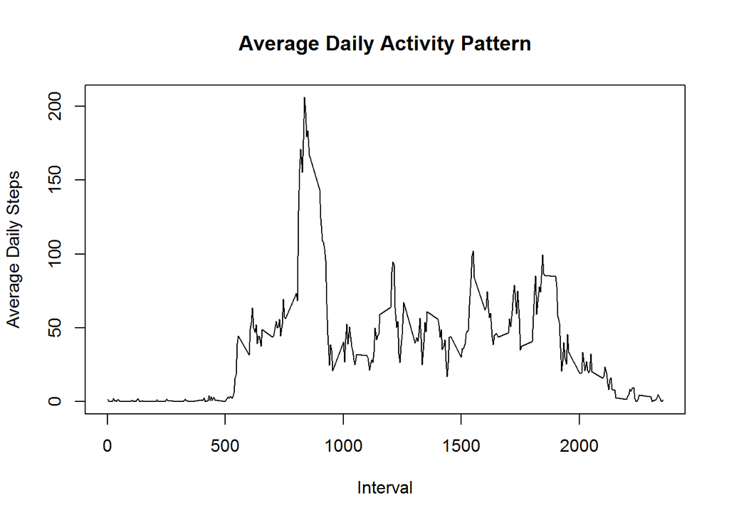

```r
dailymean <- dailymean <- aggregate(steps~interval, mydata, mean)
plot(dailymean, type='l', xlab = "Interval", ylab = "Average Daily Steps", main = "Average Daily Activity Pattern")
```

```r
temp <- dailymean[max(dailymean$steps),]
temp$interval
```

```
## [1] 1705
```

## Imputing missing values

Here, I sum the total number of NAs in the dataset.

```r
sum(is.na(mydata))
```

```
## [1] 2304
```

```r
newmydata <- mydata
sum(is.na(newmydata)) == sum(is.na(newmydata$steps))
```

```
## [1] TRUE
```

```r
mydata$steps[is.na(newmydata$steps)] <- mean(newmydata$steps, na.rm=T)
```

I then repeat the first portion by aggregating 5-minute interval into days.

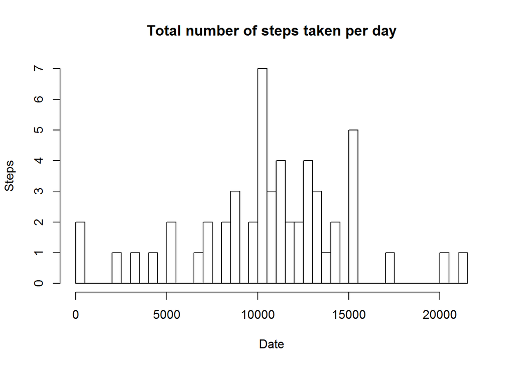

```r
NewAggregatedDates<- tapply(newmydata$steps, newmydata$date, FUN=sum)

#Breaks are set at 61, as there are 61 days from October to November.
hist(NewAggregatedDates, breaks = 61, xlab = "Date", ylab = "Steps", main = "Total number of steps taken per day")
```

```r
mean(NewAggregatedDates, na.rm = T)
```

```
## [1] 10766.19
```

```r
median(NewAggregatedDates, na.rm = T)
```

```
## [1] 10765
```

## Are there differences in activity patterns between weekdays and weekends?

We first create a new factor variable in the dataset with two levels - “weekday” and “weekend” indicating whether a given date is a weekday or weekend day.

```r
weekday.or.weekend <- function(date) {
    day <- weekdays(date)
    if (day %in% c("Monday", "Tuesday", "Wednesday", "Thursday", "Friday"))
        return("weekday") else if (day %in% c("Saturday", "Sunday"))
        return("weekend") else stop("invalid date")
}
newmydata$date <- as.Date(newmydata$date)
newmydata$day <- sapply(newmydata$date, FUN = weekday.or.weekend)
```

Then we make a panel plot containing a time series plot of the average number of of steps taken in each 5-minute interval across all weekday days or weekend days.

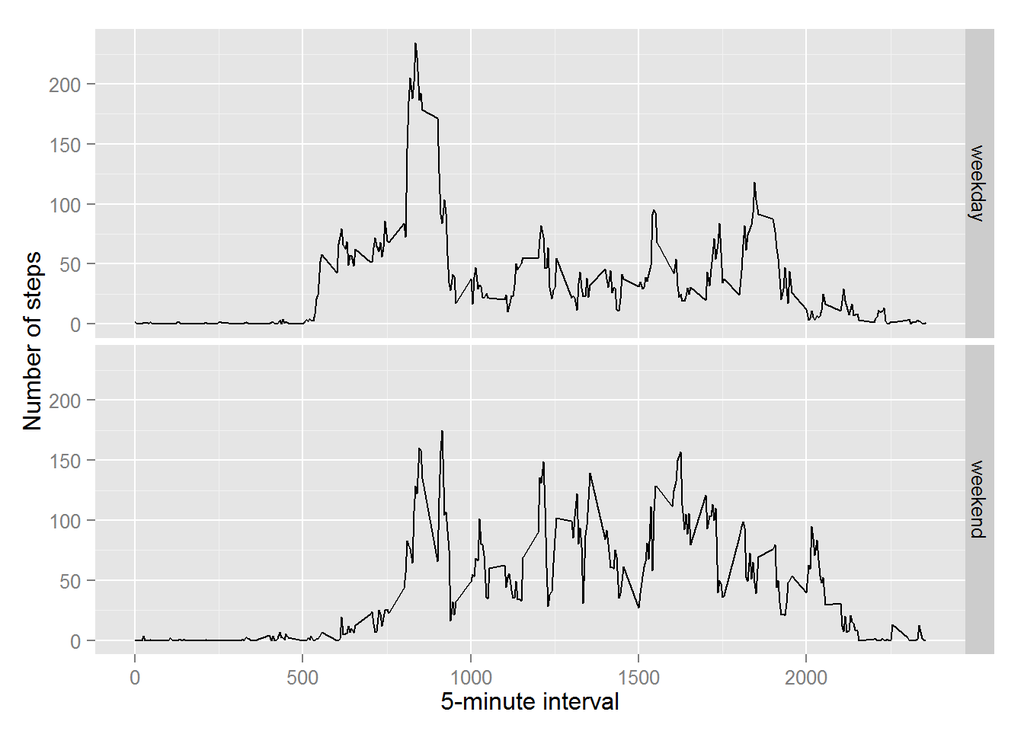

```r
require(ggplot2)
averages <- aggregate(steps ~ interval + day, data = newmydata, mean)
ggplot(averages, aes(interval, steps)) + geom_line() + facet_grid(day ~ .) +
    xlab("5-minute interval") + ylab("Number of steps")
```